# Project 1: Predict the Housing Prices in Ames

Practical Statistical Learning, Fall 2021, Ron Hong

10/18/2021

## Background

The data for this project is provided in `Ames_data.csv`. It consists of the sales prices of 2930 houses in Ames, Iowa, along with 81 possible predictors, too many to describe here. The models are evaluated with 10 splits of training and test data. The goal of this project is to minimize the RMSE of the logarithm of the sales prices between the predictions and the actual results.

```r
data = read.csv("Ames_data.csv")
testIDs = read.table("project1_testIDs.dat")
j = 2  #1-10 for each split
train = data[-testIDs[, j], ]
test = data[testIDs[, j], ]
test.y = test[, c(1, 83)]
test = test[, -83]
write.csv(train, "train.csv", row.names = FALSE)
write.csv(test, "test.csv", row.names = FALSE)
write.csv(test.y, "test_y.csv", row.names = FALSE)

source("mymain.R")

pred = read.csv("mysubmission1.txt")  #"mysubmission2.txt" for tree model
names(test.y)[2] = "True_Sale_Price"
pred = merge(pred, test.y, by = "PID")
sqrt(mean((log(pred$Sale_Price) - log(pred$True_Sale_Price)) ^ 2))
```

## Pre-processing

The pre-processing begins by replacing all the missing values in `Garage_Yr_Blt` with 0. These values will be missing if the house does not have a garage, but `Garage_Cond` contains the category `"No_Garage"`, so if a dummy variable is included for that category, what the missing values are assigned will not make any difference, as long as they are all the same.

Next, all categorical variables are replaced with dummy variables. Here, there is no reference level; other than binary categorical variables, every category receives its own dummy variable. This process is chosen because regularization prefers sparse matrices for dummy variables, and because in regression tree models, every category could cause a potential split.

Both the training and test data are prepared in this way.

## Linear model

The variables, `Lot_Frontage`, `Lot_Area`, `Mas_Vnr_Area`, `BsmtFin_SF_2`, `Bsmt_Unf_SF`, `Total_Bsmt_SF`, `First_Flr_SF`, `Second_Flr_SF`, `Gr_Liv_Area`, `Garage_Area`, `Wood_Deck_SF`, `Open_Porch_SF`, `Enclosed_Porch`, `Three_season_porch`, `Screen_Porch`, and `Misc_Val` are winsorized to the 95th percentile, reducing the effect of possible outliers on the linear regression model.

The coefficients are regularized using the elastic net, where $\alpha$ chosen from $\left\{0,\frac{1}{4},\frac{1}{2},\frac{3}{4},1\right\}$, by which value produces the lowest minimum cross-validated error. Adding potential $\alpha$ values does not significantly increase the accuracy of the model, but it will increase the running time. It appears that the minimum cross-validated error for each $\alpha$ is in the default range, so the range does not need to be changed.

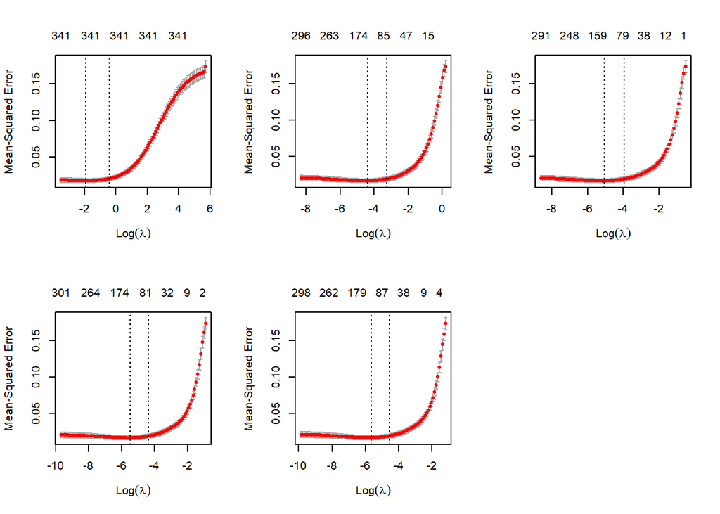

## Tree model

Gradient boosted trees from the XGBoost library are used. To prevent overfitting, half of the data is randomly subsampled when growing the trees. The step size of each boosting step and the maximum number of iterations were tuned to be $\frac{1}{32}$ and 1024 respectively.

## Results

The following running times were computed using an ASUS ROG G752VT, 2.60 GHz, 16 GB RAM.

| Split | Linear model RMSE | Tree model RMSE | Pre-processing time (s) | Linear model time (s) | Tree model time (s) |
| --- | --- | --- | --- | --- | --- |
| 1 | 0.1238078 | 0.1104463 | 0.2 | 13.0 | 13.1 |
| 2 | 0.1193541 | 0.1149587 | 0.2 | 12.8 | 13.1 |
| 3 | 0.1215815 | 0.1099659 | 0.2 | 13.2 | 13.1 |
| 4 | 0.1205149 | 0.1126662 | 0.2 | 12.6 | 13.0 |
| 5 | 0.1131867 | 0.1043632 | 0.2 | 12.5 | 13.0 |
| 6 | 0.1342150 | 0.1269914 | 0.2 | 12.8 | 13.1 |
| 7 | 0.1282500 | 0.1284058 | 0.2 | 12.5 | 13.1 |
| 8 | 0.1206533 | 0.1254798 | 0.2 | 13.1 | 13.2 |
| 9 | 0.1299658 | 0.1286176 | 0.2 | 12.3 | 13.0 |
| 10 | 0.1251821 | 0.1176153 | 0.2 | 12.4 | 13.0 |

The tree model appears to be more accurate. For 8 of the 10 splits, it has a lower RMSE, resulting in a 4.7 percent lower RMSE on average. However, the linear model is slightly faster. The running time of the linear model could be decreased if $\alpha$ were chosen once for all 10 splits, rather than individually. This approach might decrease the accuracy, but since the same data is being modeled across the 10 splits, it would not be an unreasonable one.